# Causal Inference - Exercise RCT II

Michael Knaus

SoSe 25

These are the goals of today:

- Recap identification in RCT
- Implement different hypothesis tests in the Lalonde data
- Calculate quantile treatment effect in the Lalonde data

# Identification in RCTs

We can always show identification either from observable quantities to target parameters (in lecture slides) or vice versa. Here we start with the ATE and want to proof identification as a mean difference under the independence assumption (IA) $Y(w) \perp\!\!\!\!\perp W~ for~w \in \{0,1\}$:

$$\begin{align}
SUTVA \Rightarrow E[Y(1) - Y(0)] &= E[Y(1)] - E[Y(0)] & (LOE)\\
&= E[Y(1) | W = 1] - E[Y(0) | W = 0] & (IA)\\
&= E[Y | W = 1] - E[Y | W = 0] & (Consistency)\\
\end{align}$$

# Analyzing the Lalonde RCT data set

## The data

```
# Install and load all relevant packages for this session
if (!require("tidyverse")) install.packages("tidyverse", dependencies = TRUE); library(tidyverse)
if (!require("estimatr")) install.packages("estimatr", dependencies = TRUE); library(estimatr)
if (!require("qte")) install.packages("qte", dependencies = TRUE); library(qte)
```

The famous Lalonde data stems from the US National Supported Work Demonstration. This program randomly assigned applicants to a job training program to estimate the effect on peoples yearly earning two years later. The RCT took place in the 70s.

```
data(lalonde)
?lalonde
```

First extract the treatment

```
W = lalonde.exp$treat
table(W)
```

```
W
  0   1
260 185
```

and the outcome

```
Y = lalonde.exp$re78
hist(Y)
```

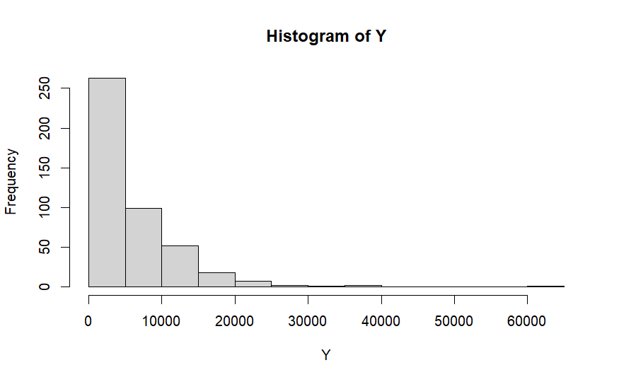

### Covariate balancing

Randomization promises to balance the covariate distribution between treated and control, though we expect it not to work perfectly with small sample sizes. This is why we always check covariate balancing. We can do this visually for age:

```
ggplot(lalonde.exp, aes(x = age, fill = factor(W))) +
  geom_histogram(aes(y = after_stat(density)),alpha = 0.5, position = "identity", bins = 30) +
  scale_fill_manual(values = c("blue", "red"), labels = c("Control", "Treated")) +
  labs(title = "Age Distribution by Treatment Group",
       x = "Age",
       fill = "Group") +
  theme_minimal()
```

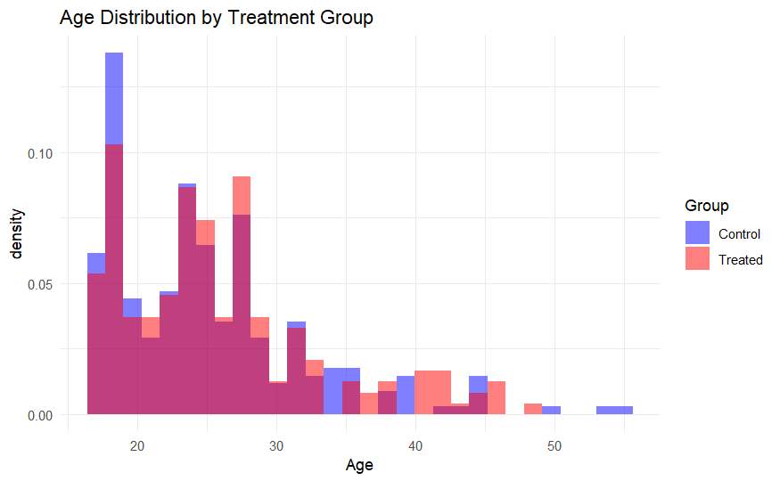

You may investigate other balancing checks for other pre-treatment variables as self-study:

```
X = model.matrix(~ 0 + age + education + black + hispanic + married + nodegree + re74 + re75, data = lalonde.exp)
```

## Hypothesis tests

### Permutation inference

First we test Fishers sharp null: $H_0: Y_i(1) = Y_i(0) \text{ or } Y_i(1) - Y_i(0) = 0 ~\forall~ i = 1,...,N$

#### Exact p-value

The exact p-value runs for ages as soon as $N>20$. Still, to illustrate the exact recipe, let’s create a random sample of $N=20$:

```
set.seed(252024) # for replicable results
index = sample(1:length(W),20)
Wsmall = W[index]
Ysmall = Y[index]
```

To get all the permutations, define the following function and see that it produces the correct permutations of $N = 4$ and $N_1 = 2$ `f(4,2)`

```
# https://stackoverflow.com/questions/28368072/create-combinations-of-a-binary-vector
f = function(n,m) combn(n,m,tabulate,nbins=n)
f(4,2)
```

```
     [,1] [,2] [,3] [,4] [,5] [,6]
[1,]    1    1    1    0    0    0
[2,]    1    0    0    1    1    0
[3,]    0    1    0    1    0    1
[4,]    0    0    1    0    1    1
```

In our small sample there are

```
choose(length(Wsmall),sum(Wsmall))
```

```
[1] 1140
```

permutations in the small data set.

Let’s implement the exact p-value recipe:

- Calculate the sample mean comparison $\hat{\tau} = \bar{Y}_1 - \bar{Y}_0$

```
tau_small = mean(Ysmall[Wsmall == 1]) - mean(Ysmall[Wsmall == 0])
tau_small
```

```
[1] 5270.478
```

- Generate all $N \choose N_1$ possible treatment assignments

```
all_permutations = f(length(Wsmall),sum(Wsmall))
dim(all_permutations)
```

```
[1]   20 1140
```

- Calculate the mean comparison for every possible treatment assignment (exact distribution under the null)

```
permuted_mcs = rep(NA,ncol(all_permutations))

for (i in 1:ncol(all_permutations)) {
  W_temp = all_permutations[,i]
  permuted_mcs[i] = mean(Ysmall[W_temp == 1]) - mean(Ysmall[W_temp == 0])
}
hist(permuted_mcs)
```

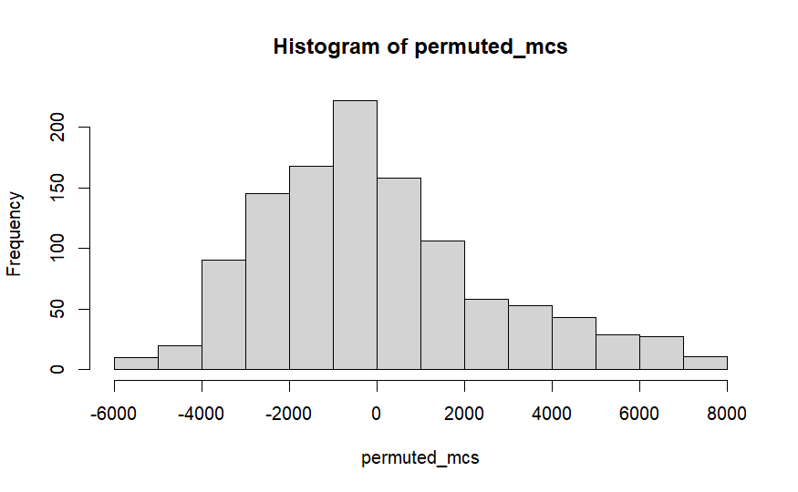

- Take their absolute values

```
hist(abs(permuted_mcs))
```

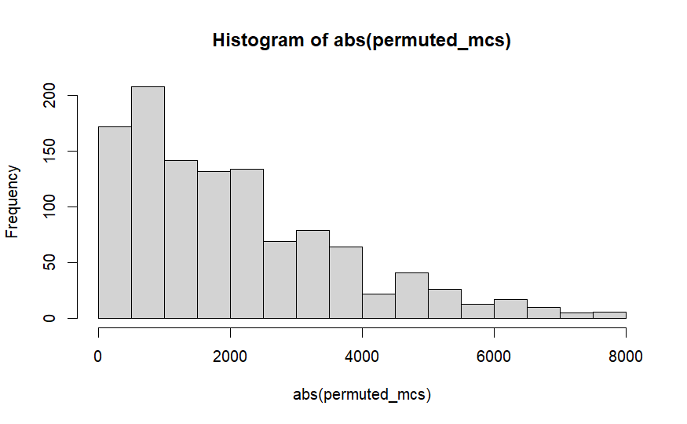

- Calculate the share of values that are $\geq |\hat{\tau}|$ $\Rightarrow$ p-value

```
pvalue_exact = mean(abs(permuted_mcs) >= tau_small)
pvalue_exact
```

```
[1] 0.05175439
```

The exact p-value in this sample of 20 observations is 0.0517544.

#### Approximate p-value

In your sample there are

```
choose(length(W),sum(W))
```

```
[1] 6.083152e+129
```

possible permutations (much more then estimated atoms in the universe…). Checking all of them runs probably for ages.

Implement the approximate p-value now in the full sample:

- Calculate the sample mean comparison $\hat{\tau} = \bar{Y}_1 - \bar{Y}_0$

```
tau_hat = mean(Y[W == 1]) - mean(Y[W == 0])
tau_hat
```

```
[1] 1794.343
```

- Calculate the mean comparison for $R$ random permutations of the treatment vector

```
tau_hat = mean(Y[W == 1]) - mean(Y[W == 0])

R = 100000
permuted_mcs = rep(NA,R)

for (i in 1:R) {
  W_temp = sample(W)
  permuted_mcs[i] = mean(Y[W_temp == 1]) - mean(Y[W_temp == 0])
}
hist(permuted_mcs)
```

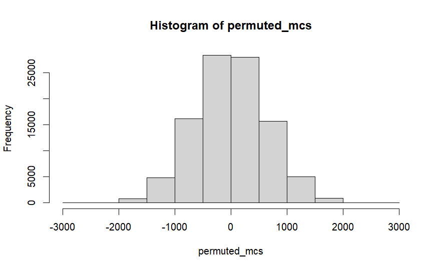

- Take their absolute values

```
hist(abs(permuted_mcs))
```

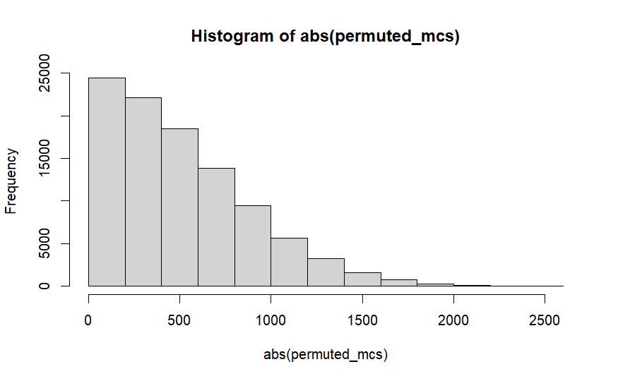

- Calculate the share of values that are $\geq |\hat{\tau}|$ $\Rightarrow$ p-value

```
pvalue_appr = mean(abs(permuted_mcs) >= tau_hat)
pvalue_appr
```

```
[1] 0.00437
```

The approximated p-value in the full sample is 0.00437.

### Testing (sample) ATE

Now hand-code the standard error of the mean comparison derived under Neymans framework:
$$\widehat{Var}[\hat{\tau}]
= \frac{\hat{\sigma}_0^2}{N_0} + \frac{\hat{\sigma}_1^2}{N_1}$$
where
$$\hat{\sigma}_0^2
=\frac{1}{N_0-1}\sum_{i} (1-W_i) \left(Y_i
- \bar{Y}_0 \right)^2$$
and
$$\hat{\sigma}_1^2
=\frac{1}{N_1-1}\sum_{i} W_i \left(Y_i
- \bar{Y}_1 \right)^2$$

```
N1 = sum(W)
N0 = sum(1-W)
# mu0 = mean(Y[W==0])
# mu1 = mean(Y[W==1])
# sigma0 = sum((1-W) * (Y - mu0)^2) / (N0-1)
# sigma1 = sum(W * (Y - mu1)^2) / (N1-1)
sigma0 = var(Y[W==0])
sigma1 = var(Y[W==1])

var_tau = sigma0 / N0 + sigma1 / N1
var_tau
```

```
[1] 450236.6
```

Calculate the standard error as $SE[\hat{\tau}] =\sqrt{\widehat{Var}[\hat{\tau}]}$

```
se_tau_hat = sqrt(var_tau)
se_tau_hat
```

```
[1] 670.9967
```

and compare it to the robust (!) standard error of the regression $Y = \alpha + \beta W + \varepsilon$:

```
tau_ols = lm_robust(Y ~ W)
summary(tau_ols)
```

```
Call:
lm_robust(formula = Y ~ W)

Standard error type:  HC2

Coefficients:
            Estimate Std. Error t value  Pr(>|t|) CI Lower CI Upper  DF
(Intercept)     4555      340.1  13.393 1.391e-34   3886.4     5223 443
W               1794      671.0   2.674 7.769e-03    475.6     3113 443

Multiple R-squared:  0.01782 ,  Adjusted R-squared:  0.01561
F-statistic: 7.151 on 1 and 443 DF,  p-value: 0.007769
```

The standard errors align and are actually identical

```
all.equal(se_tau_hat,as.numeric(tau_ols$std.error[2]))
```

```
[1] TRUE
```

$\Rightarrow$ it is convenient to just use the OLS output.

Overall, we find strong evidence that the training program increased the earning on average.

## Effect on earnings distribution

### Histogram and cdf

First check the histograms of the outcome in treated and control group to get a feeling how the empirical pdfs look like.

```
hist(Y[W==0])
```

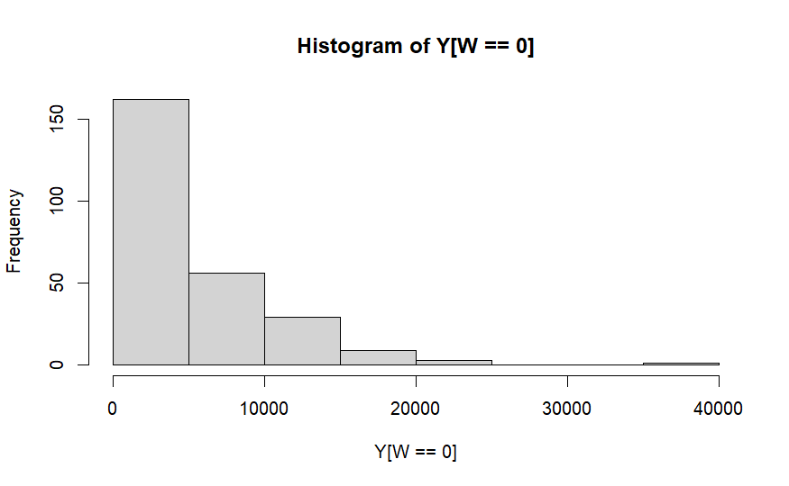

```
hist(Y[W==1])
```

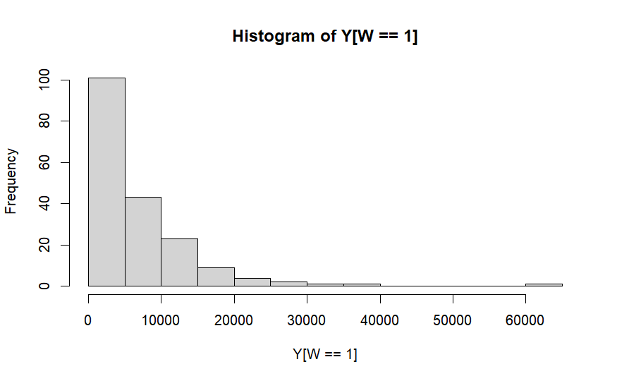

It is hard to tell from visual inspection whether they differ, so let’s plot the empirical cfds alongside:

```
ecdf1 = ecdf(Y[W==1])
ecdf0 = ecdf(Y[W==0])
ll = Map(f  = stat_function, colour = c('orange', 'blue'),
          fun = list(ecdf0, ecdf1), geom = 'step')
d = data.frame(x = c(-1,max(Y)))
ggplot(data = d, aes(x = x)) + ll + theme_bw() +
  ggtitle("cdf of controls (orange) and treated (blue)")
```

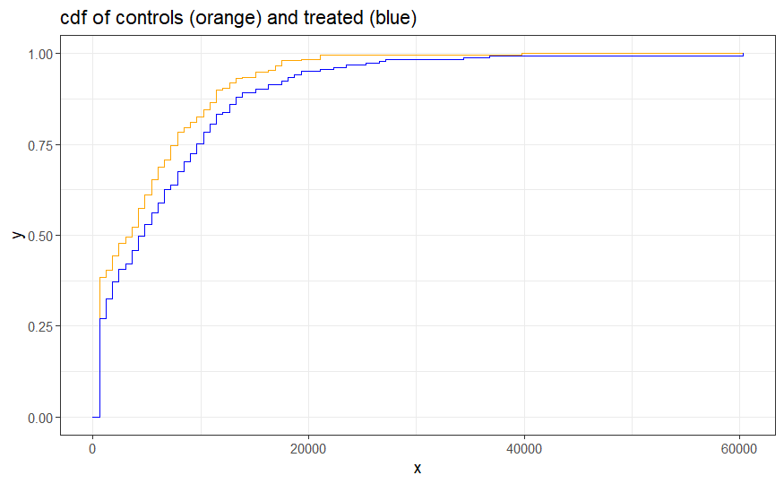

What can we say about the sign of the QTEs by simple visual inspection?

### Quantile treatment effects

Now calculate the QTEs for a grid. I choose `seq(0.05,0.95,0.05)`, but feel free to play around with the grid.

Define the grid:

```
s_grid = seq(0.05,0.95,0.05)
```

Calculate the quantiles for treated and controls:

```
Q0 = quantile(Y[W==0], probs = s_grid)
Q1 = quantile(Y[W==1], probs = s_grid)
Q0
```

```
       5%       10%       15%       20%       25%       30%       35%       40%       45%       50%       55%       60%       65%       70%       75%       80%       85%       90%
    0.000     0.000     0.000     0.000     0.000     0.000     0.000  1168.284  1959.448  3138.795  3842.798  4741.110  5306.567  6361.549  7288.418  8485.730 10287.835 11355.320
      95%
14842.810
```

```
Q1
```

```
        5%        10%        15%        20%        25%        30%        35%        40%        45%        50%        55%        60%        65%        70%        75%        80%
    0.0000     0.0000     0.0000     0.0000   485.2300   943.0472  1505.9840  2337.8260  3415.7480  4232.3100  5030.6740  6193.3960  7427.8860  8164.0720  9643.0000 10758.7800
       85%        90%        95%
12474.0600 14553.1000 18774.7000
```

Take the difference to estimate QTEs:

```
qtes = Q1 - Q0
```

Plot them:

```
plot(s_grid,qtes)
```

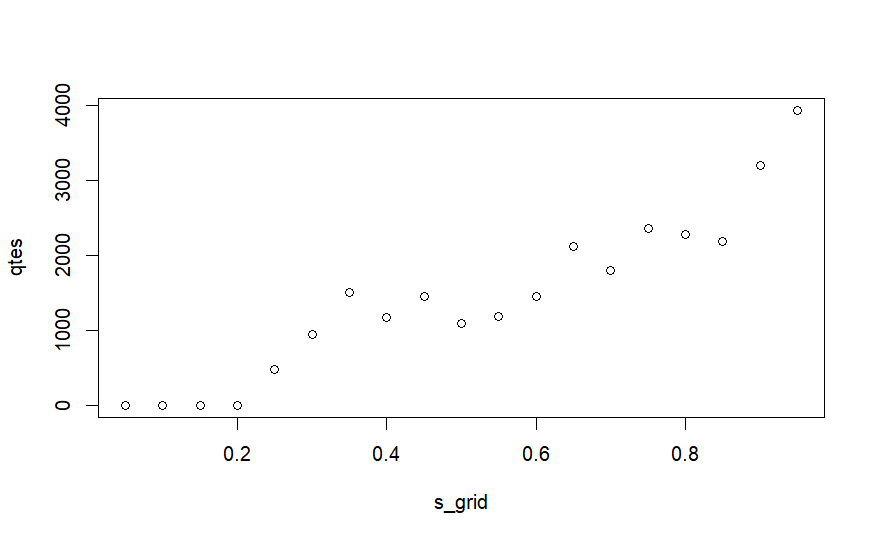

### Fast package solution

The `qte` implements everything and bootstraps the procedure to get standard errors and confidence intervals

```
qte_package = ci.qte(re78 ~ treat, data=lalonde.exp, probs = s_grid, se=T, iters=1000)
```

[output not shown]

[output cut: 46 more lines]

[output not shown]

```
summary(qte_package)
```

```
Quantile Treatment Effect:

tau QTE Std. Error
0.05       0.00    0.00
0.1    0.00    0.00
0.15       0.00   20.47
0.2    0.00  148.19
0.25     485.23  355.68
0.3  929.88  409.48
0.35    1460.36  650.77
0.4 1172.46  936.03
0.45    1553.14  959.33
0.5 1096.91  890.36
0.55    1141.42  817.93
0.6 1477.23  887.75
0.65    2155.23  927.25
0.7 1812.96 1017.31
0.75    2346.18  909.82
0.8 2291.13 1141.71
0.85    2224.97 1209.58
0.9 3117.77 1975.82
0.95    3519.67 2914.15

Average Treatment Effect:   1794.34
     Std. Error:        667.01
```

```
ggqte(qte_package)
```

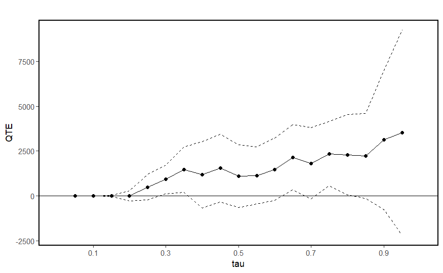

### Bootstrap manually (optional self-study)

Implement a bootstrap procedure to see if we can roughly replicate the inference results of the package.

### Completely synthetic data (optional self-study)

Illustrate rank preservation and rank reversion with synthetic data.